# Super Bowl Ads

MGinorio

## Super Bowl Analysis

#### The American Super Bowl is a statement in the Advertisement industry due to the creative nature of their ads. Every year many brands showcase their best pieces of advertisement and see which team did it better

#### This time we are asking the question - what is behind the creation of the ads? Was it funny? did it use sex to sell the product? did it feature a celebrity?

## Problem Statement

#### The aim of this analysis is to determine which category predominates in the super bowl add arena. Is it sex, comedy, animals or celebrities?

## Implementation

#### The data was scraped and manipulated accordingly for the analysis. The data was then reviewed graphically to determine what is the most used cateogry, how many times have been used over the years.

## Results

### Overview

[figure not shown]

Super Bowl

```r
url.show("https://projects.fivethirtyeight.com/super-bowl-ads/")
```

### Packages

```r
#Packages used

library(tidytext)
library(DT)
library(tm)
library(tidyverse)
library(stringr)
library(magrittr)
```

```r
library(leaflet)
library(ggplot2)
library(dplyr)
library(plotly)
library(forcats)
```

### 1.- Data Exploration

##### 1.1 Summary

###### GITHUB - place the original .csv in a github Repository and have R read from the link.

```r
superbowl_ads <-read.csv("https://raw.githubusercontent.com/mgino11/Super_Bowl_Ads_Analisys/main/HW_1_superbowl-ads.csv")

glimpse(superbowl_ads)
```

```
## Rows: 244
## Columns: 11
## $ year                      <int> 2018, 2020, 2006, 2018, 2003, 2020, 2020,...
## $ brand                     <chr> "Toyota", "Bud Light", "Bud Light", "Hynu...
## $ superbowl_ads_dot_com_url <chr> "https://superbowl-ads.com/good-odds-toyo...
## $ youtube_url               <chr> "https://www.youtube.com/watch?v=zeBZvwYQ...
## $ funny                     <chr> "False", "True", "True", "False", "True",...
## $ show_product_quickly      <chr> "False", "True", "False", "True", "True",...
## $ patriotic                 <chr> "False", "False", "False", "False", "Fals...
## $ celebrity                 <chr> "False", "True", "False", "False", "False...
## $ danger                    <chr> "False", "True", "True", "False", "True",...
## $ animals                   <chr> "False", "False", "True", "False", "True"...
## $ use_sex                   <chr> "False", "False", "False", "False", "True...
```

##### 1.2 Counting Qualitative Data

#### Brands - Who has the most adds?

##### From the information below we are able to determine that the brand with the greatest amount of ads is Budlight, followed by Budweiser and in third place we can Find Doritos.

```r
 superbowl_ads %>%
  count(brand) %>%
  arrange(desc(n))
```

```
##        brand  n
## 1  Bud Light 60
## 2  Budweiser 43
## 3    Doritos 25
## 4      Pepsi 25
## 5    Hynudai 22
## 6  Coca-Cola 21
## 7    E-Trade 13
## 8        Kia 13
## 9        NFL 11
## 10    Toyota 11
```

#### Sex

##### How many times a brand has used adds associated with sex?

```r
superbowl_ads %>%
  count(use_sex) %>%
  arrange(desc(n))
```

```
##   use_sex   n
## 1   False 181
## 2    True  63
```

#### Animals

##### How many times a brand has used adds associated with animals?

```r
superbowl_ads %>%
  count(animals) %>%
  arrange(desc(n))
```

```
##   animals   n
## 1   False 155
## 2    True  89
```

#### Funny

##### How many times a brand has used adds associated with comedy?

```r
superbowl_ads %>%
  count(funny) %>%
  arrange(desc(n))
```

```
##   funny   n
## 1  True 168
## 2 False  76
```

### 2.- Data Wrangling

###### 2.1 Subsets

Subset1 - Superbowl_ads_use

We subset data in order to understand it better. Subset_1 allows us to see the a new data frame including variables like

- Year
- Brand
- Use_sex
- Animals
- Funny
- Celebrity

```r
superbowl_ads %>% select(year, brand, funny, celebrity, animals, use_sex)
```

```
##     year     brand funny celebrity animals use_sex
## 1   2018    Toyota False     False   False   False
## 2   2020 Bud Light  True      True   False   False
## 3   2006 Bud Light  True     False    True   False
## 4   2018   Hynudai False     False   False   False
## 5   2003 Bud Light  True     False    True    True
## 6   2020    Toyota  True      True    True   False
## 7   2020 Coca-Cola  True      True    True   False
## 8   2020       Kia False      True   False   False
## 9   2020   Hynudai  True      True    True   False
## 10  2020 Budweiser False      True   False   False
## 11  2010   Hynudai False     False   False   False
## 12  2010 Bud Light  True     False   False    True
## 13  2007 Budweiser  True     False    True    True
## 14  2002 Budweiser False     False    True   False
```

[output cut: 230 more lines]

```r
head(superbowl_ads)
```

```
##   year     brand
## 1 2018    Toyota
## 2 2020 Bud Light
## 3 2006 Bud Light
## 4 2018   Hynudai
## 5 2003 Bud Light
## 6 2020    Toyota
##                                              superbowl_ads_dot_com_url
## 1                          https://superbowl-ads.com/good-odds-toyota/
## 2 https://superbowl-ads.com/2020-bud-light-seltzer-inside-posts-brain/
## 3                https://superbowl-ads.com/2006-bud-light-bear-attack/
## 4  https://superbowl-ads.com/hope-detector-nfl-super-bowl-lii-hyundai/
## 5                https://superbowl-ads.com/2003-bud-light-hermit-crab/
## 6 https://superbowl-ads.com/2020-toyota-go-places-with-cobie-smulders/
##                                   youtube_url funny show_product_quickly
## 1 https://www.youtube.com/watch?v=zeBZvwYQ-hA False                False
## 2 https://www.youtube.com/watch?v=nbbp0VW7z8w  True                 True
## 3 https://www.youtube.com/watch?v=yk0MQD5YgV8  True                False
## 4 https://www.youtube.com/watch?v=lNPccrGk77A False                 True
## 5 https://www.youtube.com/watch?v=ovQYgnXHooY  True                 True
## 6 https://www.youtube.com/watch?v=f34Ji70u3nk  True                 True
##   patriotic celebrity danger animals use_sex
## 1     False     False  False   False   False
## 2     False      True   True   False   False
## 3     False     False   True    True   False
## 4     False     False  False   False   False
## 5     False     False   True    True    True
## 6     False      True   True    True   False
```

create data frame using Tibble

```r
superbowl_ads2 <- as_tibble(superbowl_ads)
colnames(superbowl_ads2)
```

```
##  [1] "year"                      "brand"
##  [3] "superbowl_ads_dot_com_url" "youtube_url"
##  [5] "funny"                     "show_product_quickly"
##  [7] "patriotic"                 "celebrity"
##  [9] "danger"                    "animals"
## [11] "use_sex"
```

###### Factor $ Levels

Subset_1 = superbowl_ads2

In order to understand Categorical Data we need to use Levels and factors. The package used for this task is forcats

```r
glimpse(superbowl_ads2)
```

```
## Rows: 244
## Columns: 11
## $ year                      <int> 2018, 2020, 2006, 2018, 2003, 2020, 2020,...
## $ brand                     <chr> "Toyota", "Bud Light", "Bud Light", "Hynu...
## $ superbowl_ads_dot_com_url <chr> "https://superbowl-ads.com/good-odds-toyo...
## $ youtube_url               <chr> "https://www.youtube.com/watch?v=zeBZvwYQ...
## $ funny                     <chr> "False", "True", "True", "False", "True",...
## $ show_product_quickly      <chr> "False", "True", "False", "True", "True",...
## $ patriotic                 <chr> "False", "False", "False", "False", "Fals...
## $ celebrity                 <chr> "False", "True", "False", "False", "False...
## $ danger                    <chr> "False", "True", "True", "False", "True",...
## $ animals                   <chr> "False", "False", "True", "False", "True"...
## $ use_sex                   <chr> "False", "False", "False", "False", "True...
```

```r
superbowl_ads2 %>%
  mutate(funny = fct_lump(funny, n = 50)) %>%
  count(funny)
```

```
## # A tibble: 2 x 2
##   funny     n
## * <fct> <int>
## 1 False    76
## 2 True    168
```

Subset_2

```r
superbowl_ads2 %>%
  count(use_sex, celebrity)
```

```
## # A tibble: 4 x 3
##   use_sex celebrity     n
##   <chr>   <chr>     <int>
## 1 False   False       135
## 2 False   True         46
## 3 True    False        41
## 4 True    True         22
```

### 3.- Graphs

###### subset_1

We want to interpret graphically the frequency of ads that use sex

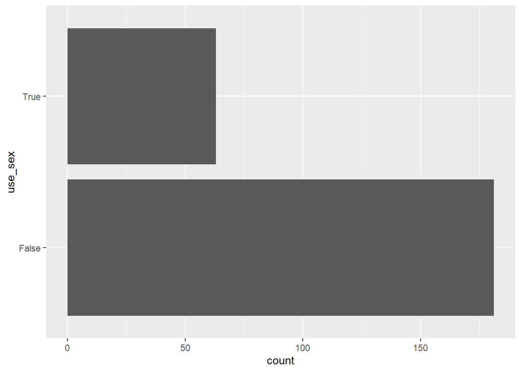

```r
ggplot(superbowl_ads2, aes(x = use_sex)) +
  geom_bar() +
  coord_flip()
```

We want to interpret graphically the frequency of funny ads

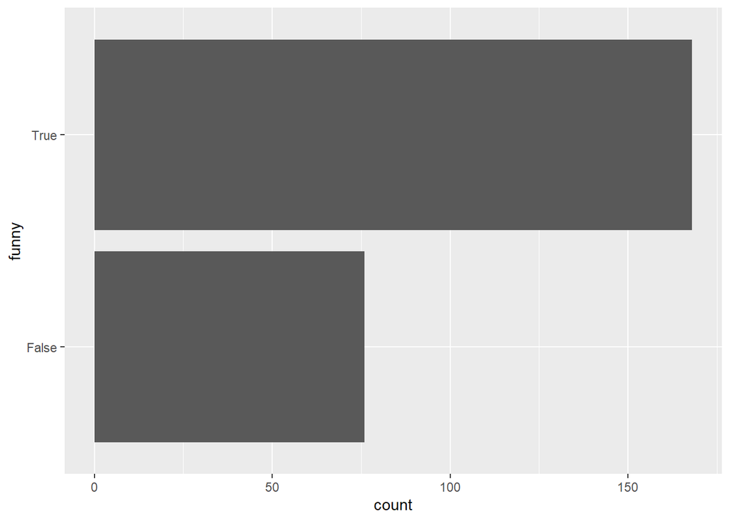

```r
ggplot(superbowl_ads2, aes(x = funny)) +
  geom_bar() +
  coord_flip()
```

We want to compare the use of sex in ads vs. the use of comedy. We can clearly see that comedy has been used more than sex.

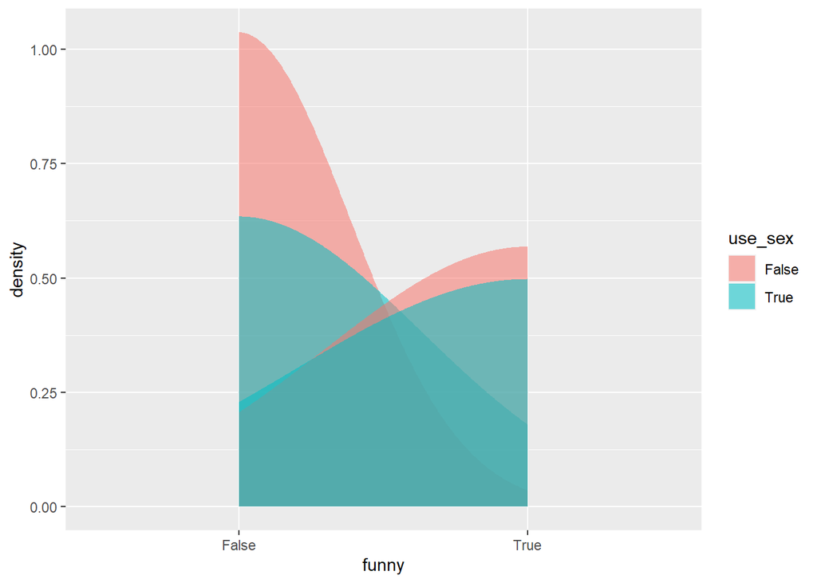

```r
ggplot(superbowl_ads2, aes(x = funny, fill = use_sex)) +
  geom_density(col = NA, alpha = 0.55)
```

### 4.- Conclusion

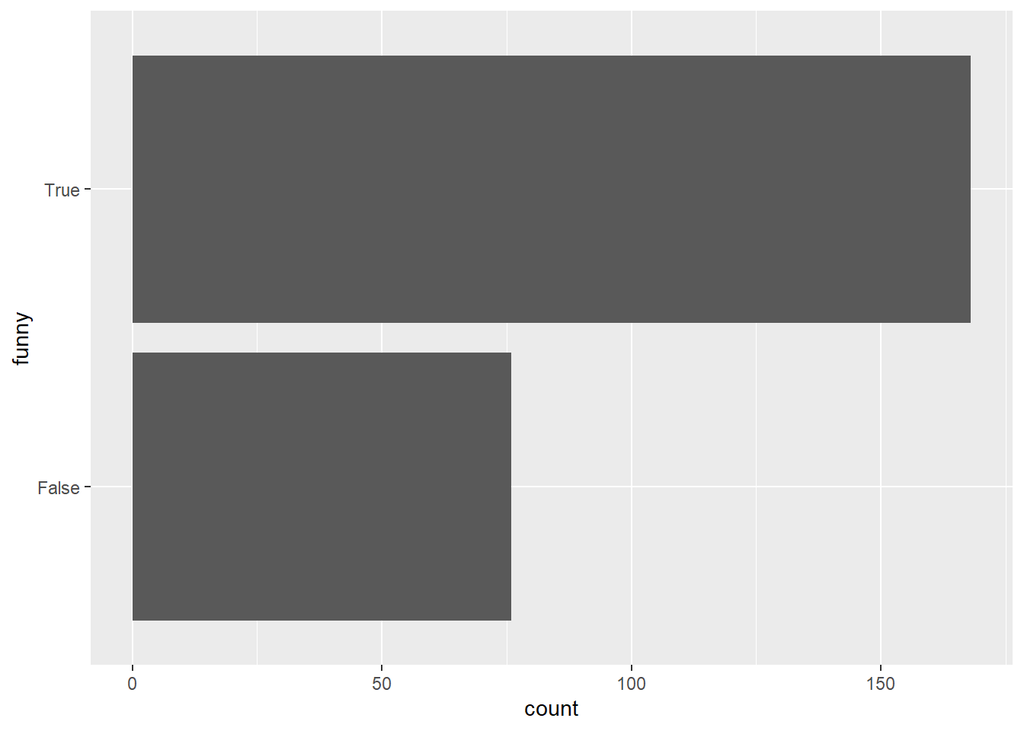

```r
ggplot(superbowl_ads2, aes(x = funny)) +
  geom_bar() +
  coord_flip()
```

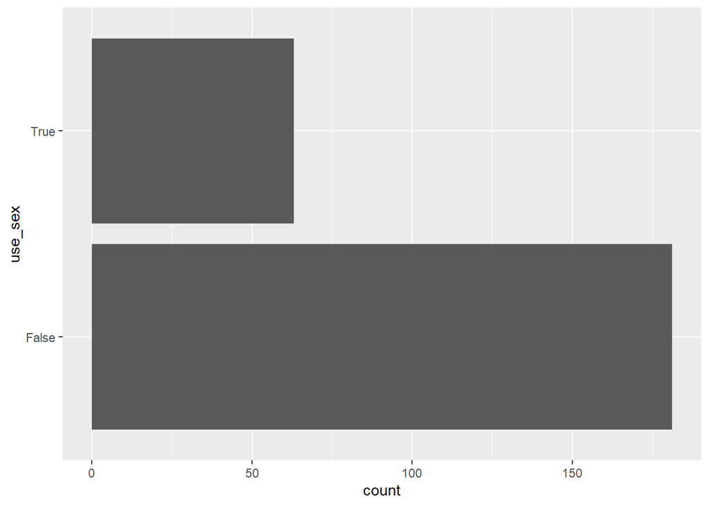

```r
ggplot(superbowl_ads2, aes(x = use_sex)) +
  geom_bar() +
  coord_flip()
```

#### SEX vs. funny (different view)

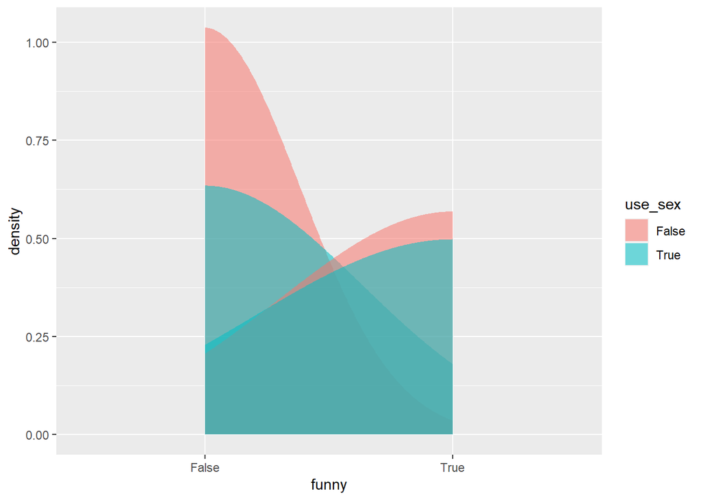

```r
ggplot(superbowl_ads2, aes(x = funny, fill = use_sex)) +
  geom_density(col = NA, alpha = 0.55)
```